# Second Steps with R (non-credit lab)

Colin Conrad

13/03/2021

This is a second introductory tutorial on R programming using the Greenhouse Gas datasets. This document was created in Jupyter Notebook and provides copies of code (with explanations) which you can try in your own R environment. It is assumed that you have successfully installed R (not recommended), R Studio (recommended) or Anaconda on your computer before starting this and that you have completed “Getting Started with R”.

**Use of this document is subject to the terms of the [MIT Open Source License](https://opensource.org/licenses/MIT)**

### What to submit

This lab is so *extra* (ok, bad joke). Seriously, this is non-credit, meaning that you cannot submit it for grades. However, I thought that some of you might find it useful, in case you want to dig more deeply into the R programming language.

## Load a data frame and understand the data

Picking up from the last tutorial, you should be familiar with a few key concepts. To summarize, in programming languages we can save variables (e.g. integers, floats and strings).In R, we can easily save vectors (series of similar variables). Combinations of vectors can be assembled into a data frame, which is a spreadsheet-like format. R allows us to easily create high quality (publishable, even) graphs.

This week we will move beyond the bare basics and start working with the climate change data directly. Currently, the data is saved as a CSV file (comma separated values file) in our local folder. We can load that CSV file into our environment and save it as a data frame. The following code accomplishes this.

```r
dat <- read.csv('data/extra_GHG.csv') # loads the data frame from csv
```

It’s always good to learn about our data frame by retrieving a summary. Let’s retrieve a summary of the structure of our data using the `str` function.

```r
str(dat) # give a summary of the data's structure
```

```
## 'data.frame':    16250 obs. of  10 variables:
##  $ Year          : int  1990 1990 1990 1990 1990 1990 1990 1990 1990 1990 ...
##  $ Region        : chr  "Alberta" "Alberta" "Alberta" "Alberta" ...
##  $ Index         : int  0 1 2 3 4 5 6 8 9 10 ...
##  $ Source        : chr  "Provincial Inventory Total" "Oil and Gas" "Oil and Gas" "Oil and Gas" ...
##  $ Sector        : chr  "" "" "Upstream Oil and Gas" "Upstream Oil and Gas" ...
##  $ Sub.sector    : chr  "" "" "" "Natural Gas Production and Processing" ...
##  $ Sub.sub.sector: chr  "" "" "" "" ...
##  $ Total         : chr  "y" "y" "y" "" ...
##  $ CO2eq         : chr  "173.0523683" "67.57525298" "63.93934941" "29.09710967" ...
##  $ Unit          : chr  "Mt" "Mt" "Mt" "Mt" ...
```

From your experience last week, you can probably see the advantages of the data frame format. This structure is easily navigable in terms of vectors and variables. For example, if we wished to retrieve only the CO2eq values and save them as a vector, we could try the following.

```r
CO2eq_values <- dat$CO2eq # retrieves the CO2eq vector
```

Similarly, if we wished to retrieve only the first CO2eq value in the data frame (representing Alberta’s total in 1990) we could do the following.

```r
alta_1990 <- dat$CO2eq[1] # retrieves the CO2eq for Alberta in 1990
```

Let’s dig slightly deeper. While `str()` summarized the data’s structure, it did not give us a clear understanding of the statistical values in the data. By default, R has the `summary()` function to achieve this. Try implementing `summary()` to learn more about the data.

```r
summary(dat) # retrieves a statistical summary of the data frame
```

```
##       Year         Region              Index          Source
##  Min.   :1990   Length:16250       Min.   : 0.00   Length:16250
##  1st Qu.:1997   Class :character   1st Qu.:16.00   Class :character
##  Median :2004   Mode  :character   Median :26.00   Mode  :character
##  Mean   :2004                      Mean   :25.76
##  3rd Qu.:2011                      3rd Qu.:37.00
##  Max.   :2018                      Max.   :48.00
##     Sector           Sub.sector        Sub.sub.sector        Total
##  Length:16250       Length:16250       Length:16250       Length:16250
##  Class :character   Class :character   Class :character   Class :character
##  Mode  :character   Mode  :character   Mode  :character   Mode  :character
##
##
##
##     CO2eq               Unit
##  Length:16250       Length:16250
##  Class :character   Class :character
##  Mode  :character   Mode  :character
##
##
##
```

Finally, we can also retrieve the first six values of the data using `head()`. This can be useful for getting a detailed idea of what the data frame looks like without digging into the whole set.

```r
head(dat)
```

```
##   Year  Region Index                     Source               Sector
## 1 1990 Alberta     0 Provincial Inventory Total
## 2 1990 Alberta     1                Oil and Gas
## 3 1990 Alberta     2                Oil and Gas Upstream Oil and Gas
## 4 1990 Alberta     3                Oil and Gas Upstream Oil and Gas
## 5 1990 Alberta     4                Oil and Gas Upstream Oil and Gas
## 6 1990 Alberta     5                Oil and Gas Upstream Oil and Gas
##                              Sub.sector                    Sub.sub.sector Total
## 1                                                                             y
## 2                                                                             y
## 3                                                                             y
## 4 Natural Gas Production and Processing
## 5           Conventional Oil Production                                       y
## 6           Conventional Oil Production Conventional Light Oil Production
##         CO2eq Unit
## 1 173.0523683   Mt
## 2 67.57525298   Mt
## 3 63.93934941   Mt
## 4 29.09710967   Mt
## 5 15.97307867   Mt
## 6 8.810367125   Mt
```

### Challenge Question 1 (1 point)

Similarly to `head()` you can use `tail()` to retrieve the last 6 rows of the data frame. Try implementing `tail()` to retrieve these values. What do these represent?

## Plot Canada’s GHG emissions over time

With a data frame in hand, we can now re-create what we did last week, but more elegantly (or so you would think). At first glance, it seems like we could easily create a graph of this data which displays changes in emissions over time. However, the data is structured in a way that makes this difficult, as many of the values are summations of other values. For example, the plotting code that we used last week would not be sufficient for navigating this data frame.

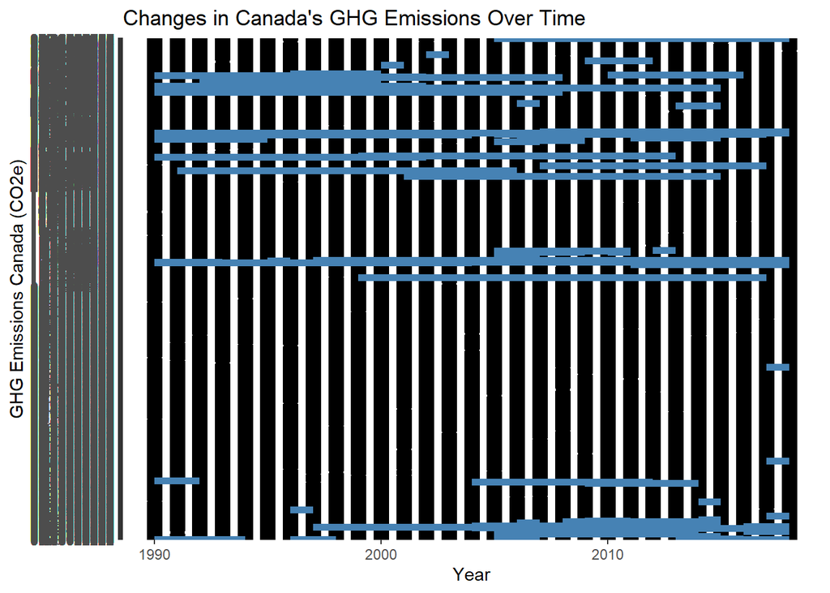

```r
# NOTE: this might make your computer angry

library(ggplot2) # import ggplot 2

ggplot(dat, aes(Year, CO2eq)) + # specify the data, and the aesthetic mapping
  geom_point(shape=21, color="black", fill="black", size=4) + # specify points
  geom_line(color="steelblue", size=2) + # specify the line
  xlab("Year") + # x label
  ylab("GHG Emissions Canada (CO2e)") + # y label
  ggtitle("Changes in Canada's GHG Emissions Over Time") # graph title
```

What we need is an effective way to navigate the data using . Fortunately, the `dplyr` makes this pretty easy, especially if you are familiar with SQL. It would be desirable to create a new data frame consisting only of the total GHG emissions for Canada over time. We could create such a data frame using the following code. You can [read more about the library here](https://www.rdocumentation.org/packages/dplyr/versions/0.7.8).

```r
library(dplyr) # note you might have to install this if you don't already have it
totals <- dat %>% # create a selection of dat
  select(Year, Region, Index, CO2eq) %>% # select only the these columns
  filter(Region == "Canada") %>% # apply a filter for only Canada (no provinces)
  filter(Index == 0) # apply a filter for Index 0, which is total emissions
```

```r
head(totals) # summarize the new data frame
```

```
##   Year Region Index       CO2eq
## 1 1990 Canada     0 603.2200911
## 2 1991 Canada     0 594.8725076
## 3 1992 Canada     0 612.4617661
## 4 1993 Canada     0 615.0478947
## 5 1994 Canada     0 636.3731323
## 6 1995 Canada     0  653.055777
```

This should look familiar, as these are the Year and CO2eq values that we saw last week, though as floats rather than integers. We should thus be able to apply them to a graph. However, there is an issue with the CO2eq– this has been converted to a `chr` type rather than a numeric type. If we graph it using the code below, ggplot2 will not know how to plot the line.

```
## geom_path: Each group consists of only one observation. Do you need to adjust
## the group aesthetic?
```

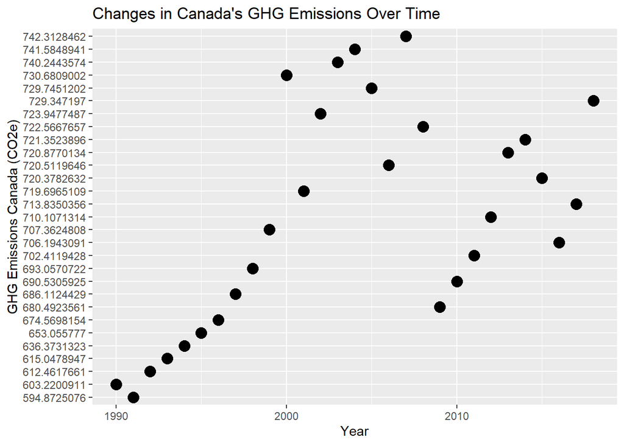

```r
ggplot(totals, aes(Year, CO2eq)) + # specify the data, and the aesthetic mapping
  geom_point(shape=21, color="black", fill="black", size=4) + # specify points
  geom_line(color="steelblue", size=2) + # specify the line
  xlab("Year") + # x label
  ylab("GHG Emissions Canada (CO2e)") + # y label
  ggtitle("Changes in Canada's GHG Emissions Over Time") # graph title
```

We can fix this by using the `as.numeric()` function, which converts a variable or vector to a numeric type. Use the code below to change the type and run the graph again.

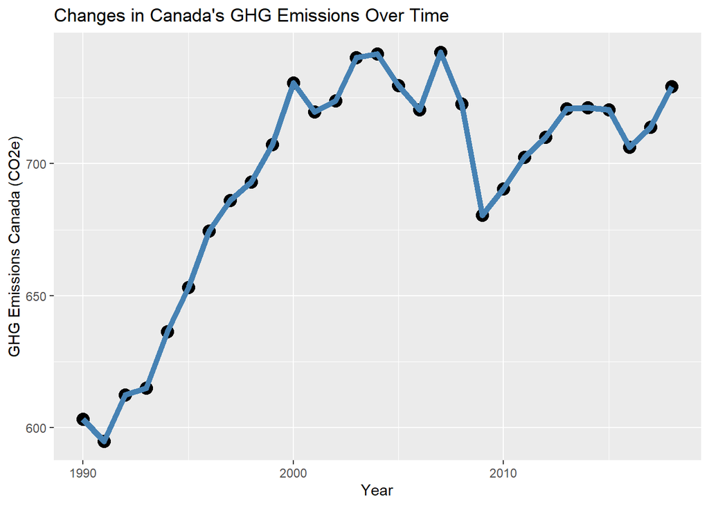

```r
totals$CO2eq <- as.numeric(totals$CO2eq) # converts the totals to numeric type

ggplot(totals, aes(Year, CO2eq)) + # specify the data, and the aesthetic mapping
  geom_point(shape=21, color="black", fill="black", size=4) + # specify points
  geom_line(color="steelblue", size=2) + # specify the line
  xlab("Year") + # x label
  ylab("GHG Emissions Canada (CO2e)") + # y label
  ggtitle("Changes in Canada's GHG Emissions Over Time") # graph title
```

### Challenge Question 2 (1 point)

Can you modify the code above to retrieve the total emissions for Nova Scotia over time? Create a graph from this data.

## Expand into oil and gas

We can start by creating a new data frame that is a subset of the general data set. To retrieve these values, we would need to specify index values 1 and 16. We can use the “or” operator (expressed as `|` to do this). The code below creates a new data frame called `gas_electric`.

```r
gas_electric <- dat %>% # create a selection of dat
  select(Year, Region, Index, Source, CO2eq) %>% # select only the these columns
  filter(Region == "Canada") %>% # apply a filter for only Canada (no provinces)
  filter(Index == 1 | Index == 16) # 1: oil and gas total, 16: electricity
```

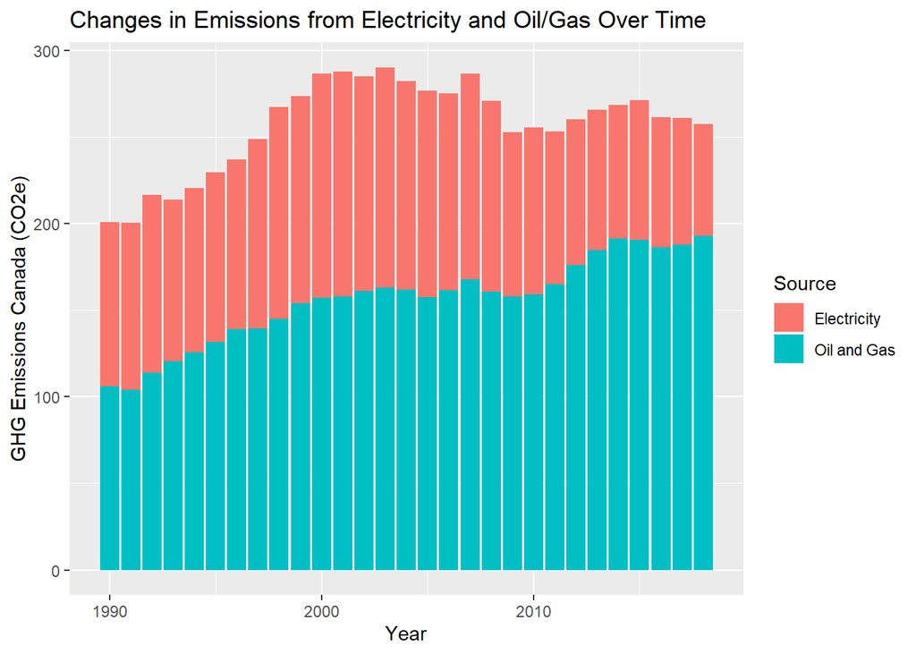

```r
ggplot(gas_electric, aes(x=Year, y=as.numeric(CO2eq), fill=Source)) + # specify the data, and the aesthetic mapping, including the source
  geom_bar(position="stack", stat="identity") + # geom bar does the trick
  xlab("Year") + # x label
  ylab("GHG Emissions Canada (CO2e)") + # y label
  ggtitle("Changes in Emissions from Electricity and Oil/Gas Over Time") # graph title
```

### Challenge Question 3 (1 point)

How have the emissions from Canada’s heavy industry fared over time? Modify the code above to create a graph that also includes Canada’s heavy industry. Index 25 accounts for all sources related to heavy industry.

## Assess the potential for policy impacts in Nova Scotia

The Government of Canada recently released the details of its [substantial climate action plan](https://www.cbc.ca/news/politics/net-zero-carbon-climate-trudeau-1.5838736), including tangible steps to meet its current climate action commitments. A large part of this plan concerns the electrification of Canada’s home and transportation sectors. We can ask whether these initiatives could have an impact on Nova Scotia’s overall GHG emissions.

To assess this, we can observe a specific ponit in time in the data, for example, just the emissions from 2018. The code below retrieves the values from NS for 2018, with only the top level indices for each of the sources.

```r
ns <- dat %>% # create a selection of dat
  select(Year, Region, Index, Source, CO2eq) %>% # select only the these columns
  filter(Region == "Nova Scotia") %>% # apply a filter for only Nova Scotia
  filter(Year == "2018") %>% # apply a filter for only Nova Scotia
  filter(Index == 1 | # oil and gas production
           Index == 16 | # electricity
           Index == 17 | # transportation
           Index == 25 | # heavy industry
           Index == 33 | # buildings
           Index == 36 | # agriculture
           Index == 40 | # waste
           Index == 44 | # coal production
           Index == 45 # light industry
         )
```

With this in hand, we can visualize the various sources of Nova Scotia’s emissions in 2018. This time, we can plot the categories on the y axis to improve readability. It will become clear that electrification of Nova Scotia’s transportation sector (i.e. electric cars) can help, though given that much of our emissions are from electricity, it might make more sense to invest in clean energy first.

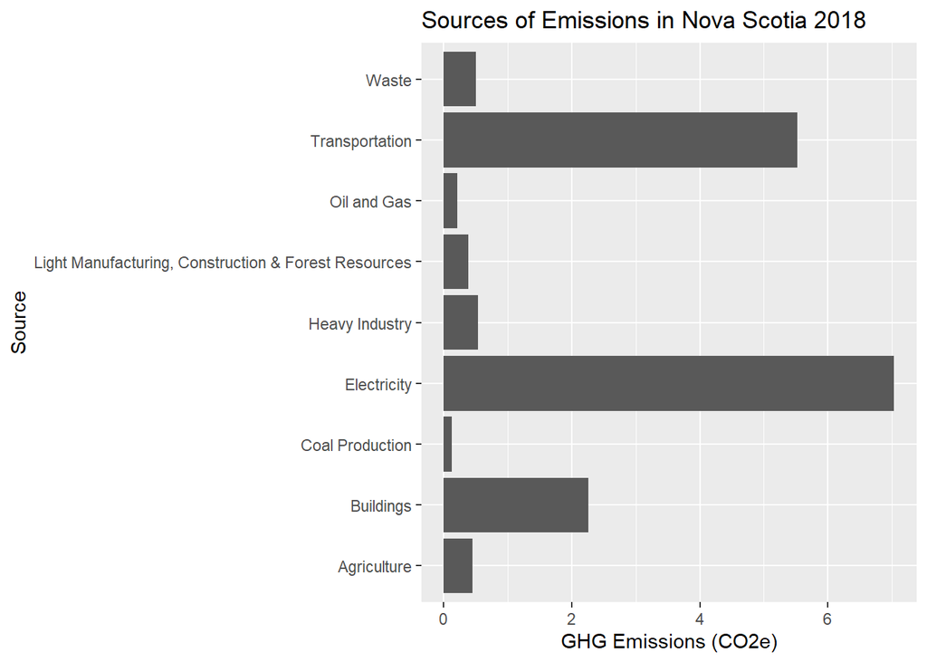

```r
ggplot(ns, aes(x=as.numeric(CO2eq),y=Source)) + # plot y as the categorical variables
  geom_bar(position="stack", stat="identity") +
  xlab("GHG Emissions (CO2e)") + # x label
  ylab("Source") + # y label
  ggtitle("Sources of Emissions in Nova Scotia 2018") # graph title
```

### Challenge Question 4 (2 points)

Based on what you learned in this lab, try to identify the major sources of emissions for other provinces (e.g. Ontario, Quebec). Do you think that the government’s policy can help lower emissions in these provinces? What about Alberta and Saskatchewan?

**After completing this question you should be ready to start exploring on your own, and work your way to productivity. I hope this was a useful introduction to R!**